# Main Project: Pattern Discovery with Unsupervised Learning

### Check Cluster Sizes

```python
# Cluster counts

hierarchical_cluster_counts = (
    df_hierarchical['Hierarchical_Cluster']
    .value_counts()
    .sort_index()
)

hierarchical_cluster_distribution = pd.DataFrame({
    'Customer Count': hierarchical_cluster_counts,
    'Percentage': (
        hierarchical_cluster_counts /
        len(df_hierarchical) * 100
    ).round(2)
})

hierarchical_cluster_distribution
```

| Hierarchical_Cluster | Customer Count | Percentage |
| --- | --- | --- |
| 1 | 50 | 7.58 |
| 2 | 610 | 92.42 |

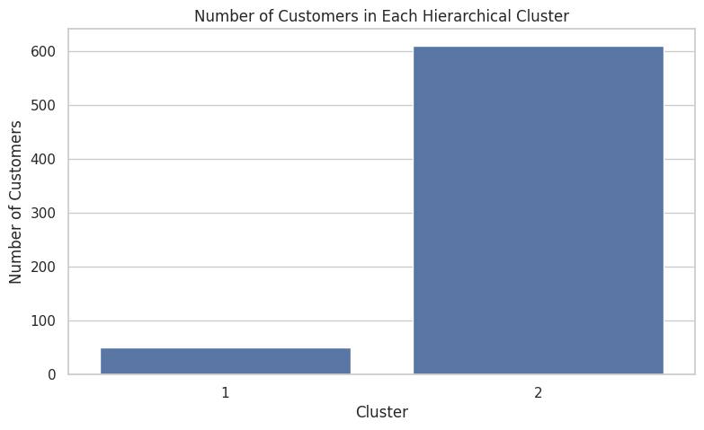

```python
plt.figure(figsize=(9, 5))

sns.barplot(
    x=hierarchical_cluster_distribution.index.astype(str),
    y=hierarchical_cluster_distribution['Customer Count']
)

plt.title('Number of Customers in Each Hierarchical Cluster')
plt.xlabel('Cluster')
plt.ylabel('Number of Customers')

plt.show()
```

### Observation

The final hierarchical clustering solution divides the 660 customers into distinct groups of different sizes.

The cluster sizes are examined to ensure that the solution does not produce an excessive number of extremely small clusters and that each segment has sufficient customers for meaningful business interpretation.

### 4.3 Hierarchical Cluster Profiling

The final hierarchical clusters are profiled using the original customer variables rather than the standardized values.

Using the original units makes the clusters easier to interpret from a business perspective.

```python
# Profile hierarchical clusters using original values

hierarchical_profile = (
    df_hierarchical
    .groupby('Hierarchical_Cluster')[cluster_features]
    .mean()
)

hierarchical_profile.round(2)
```

| Hierarchical_Cluster | Avg_Credit_Limit | Total_Credit_Cards | Total_visits_bank | Total_visits_online | Total_calls_made |
| --- | --- | --- | --- | --- | --- |
| 1 | 141040.00 | 8.74 | 0.60 | 10.90 | 1.08 |
| 2 | 25847.54 | 4.38 | 2.55 | 1.93 | 3.79 |

### Hierarchical Cluster Profile Heatmap

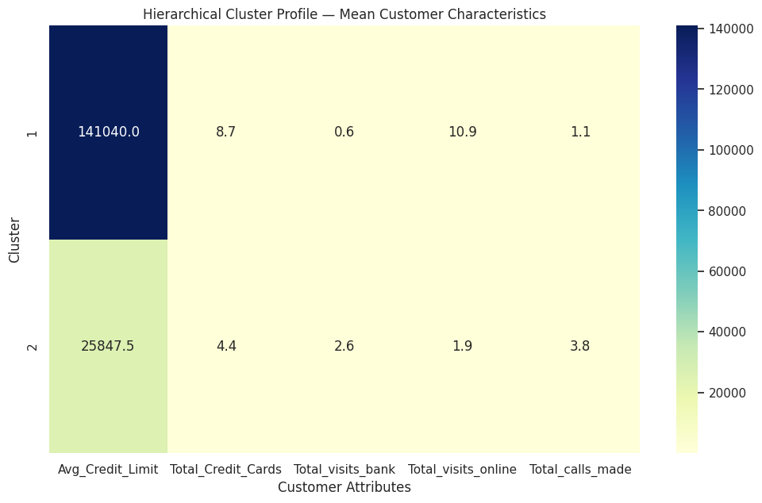

```python
plt.figure(figsize=(12, 7))

sns.heatmap(
    hierarchical_profile,
    annot=True,
    fmt='.1f',
    cmap='YlGnBu'
)

plt.title(
    'Hierarchical Cluster Profile — '
    'Mean Customer Characteristics'
)

plt.xlabel('Customer Attributes')
plt.ylabel('Cluster')

plt.show()
```

### Detailed Cluster Profile

```python
# Detailed hierarchical cluster statistics

hierarchical_detailed_profile = (
    df_hierarchical
    .groupby('Hierarchical_Cluster')[cluster_features]
    .agg(['count', 'mean', 'median', 'min', 'max'])
)

hierarchical_detailed_profile.round(2)
```

| Hierarchical_Cluster | Avg_Credit_Limit count | Avg_Credit_Limit mean | Avg_Credit_Limit median | Avg_Credit_Limit min | Avg_Credit_Limit max | Total_Credit_Cards count | Total_Credit_Cards mean | Total_Credit_Cards median | Total_Credit_Cards min | Total_Credit_Cards max | Total_visits_bank count | Total_visits_bank mean | Total_visits_bank median | Total_visits_bank min | Total_visits_bank max | Total_visits_online count | Total_visits_online mean | Total_visits_online median | Total_visits_online min | Total_visits_online max | Total_calls_made count | Total_calls_made mean | Total_calls_made median | Total_calls_made min | Total_calls_made max |
| --- | --- | --- | --- | --- | --- | --- | --- | --- | --- | --- | --- | --- | --- | --- | --- | --- | --- | --- | --- | --- | --- | --- | --- | --- | --- |
| 1 | 50 | 141040.00 | 145500.00 | 84000 | 200000 | 50 | 8.74 | 9.00 | 5 | 10 | 50 | 0.60 | 1.00 | 0 | 1 | 50 | 10.90 | 11.00 | 6 | 15 | 50 | 1.08 | 1.00 | 0 | 3 |
| 2 | 610 | 25847.54 | 17000.00 | 3000 | 100000 | 610 | 4.38 | 4.00 | 1 | 7 | 610 | 2.55 | 2.00 | 0 | 5 | 610 | 1.93 | 2.00 | 0 | 10 | 610 | 3.79 | 3.00 | 0 | 10 |

### Standardized Cluster Profile

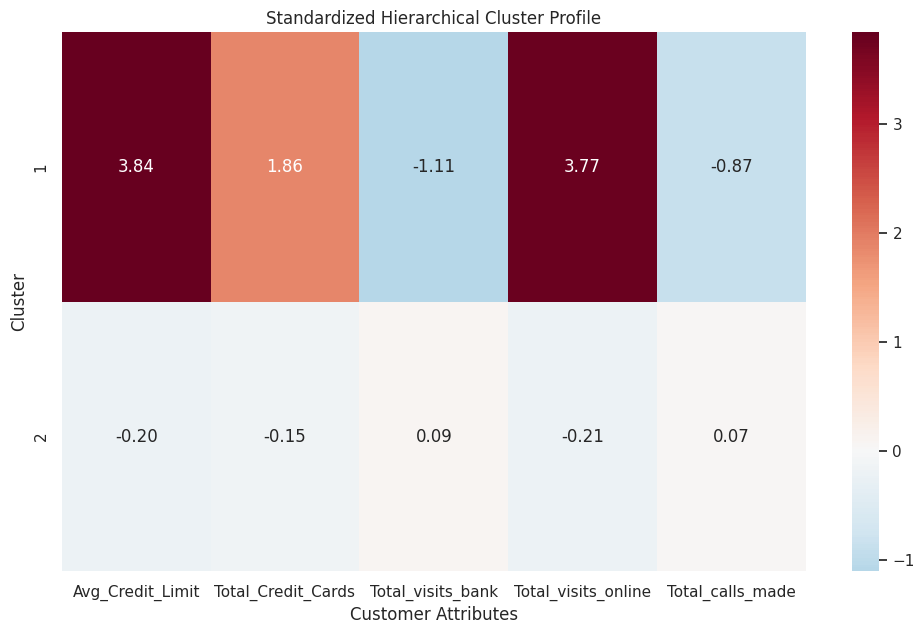

```python
# Standardized cluster profile for relative comparison

hierarchical_profile_scaled = pd.DataFrame(
    scaler.transform(hierarchical_profile),
    columns=cluster_features,
    index=hierarchical_profile.index
)

plt.figure(figsize=(12, 7))

sns.heatmap(
    hierarchical_profile_scaled,
    annot=True,
    fmt='.2f',
    cmap='RdBu_r',
    center=0
)

plt.title(
    'Standardized Hierarchical Cluster Profile'
)

plt.xlabel('Customer Attributes')
plt.ylabel('Cluster')

plt.show()
```

### Observation

The standardized profile highlights how each hierarchical cluster differs from the overall customer population.

Clusters can be interpreted based on their relative levels of credit limit, credit-card ownership, branch visits, online visits, and call-center interactions.

These differences will be used later to develop customer segment profiles and actionable recommendations.

### PCA Visualization of Hierarchical Clusters

```python
# Use PCA only to visualize hierarchical clusters in 2D

pca_hierarchical = PCA(n_components=2)

hierarchical_pca_data = pca_hierarchical.fit_transform(
    scaled_data
)

hierarchical_pca_df = pd.DataFrame(
    hierarchical_pca_data,
    columns=['PC1', 'PC2']
)

hierarchical_pca_df['Cluster'] = hierarchical_labels

print(
    "PC1 variance explained:",
    round(
        pca_hierarchical.explained_variance_ratio_[0] * 100,
        2
    ),
    "%"
)

print(
    "PC2 variance explained:",
    round(
        pca_hierarchical.explained_variance_ratio_[1] * 100,
        2
    ),
    "%"
)
```

```
PC1 variance explained: 47.2 %
PC2 variance explained: 34.52 %
```

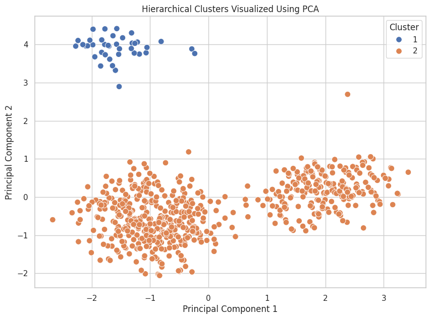

```python
plt.figure(figsize=(10, 7))

sns.scatterplot(
    data=hierarchical_pca_df,
    x='PC1',
    y='PC2',
    hue='Cluster',
    palette='deep',
    s=70
)

plt.title(
    'Hierarchical Clusters Visualized Using PCA'
)

plt.xlabel('Principal Component 1')
plt.ylabel('Principal Component 2')

plt.legend(title='Cluster')

plt.show()
```

### Observation

The PCA visualization provides a two-dimensional representation of the hierarchical clusters.

PCA is used only to visualize the five-dimensional customer data. The hierarchical clustering model itself is based on all five standardized customer attributes.

The visualization provides an additional qualitative assessment of how the identified customer groups are positioned relative to each other.

## 4.4 Hierarchical Clustering — Summary

Agglomerative hierarchical clustering was applied using four linkage methods: Single, Complete, Average, and Ward.

The dendrograms for all linkage methods were examined to understand the hierarchical structure of the customer population.

Cophenetic correlation was calculated for each linkage method to assess how faithfully each dendrogram represented the original pairwise distances. The linkage method with the highest cophenetic correlation was selected for the final hierarchical clustering model.

The appropriate number of clusters was evaluated using the dendrogram structure and silhouette scores for candidate cluster counts.

The final hierarchical clusters were then profiled using the original customer attributes to identify differences in financial characteristics and interaction behavior.

The resulting segments provide an alternative customer segmentation to the K-Means solution and will be compared with K-Means in the next section.

## 5. K-Means vs Hierarchical Clustering

K-Means and hierarchical clustering were applied to the same five standardized customer attributes to identify meaningful customer segments.

The two approaches are compared based on:

- Number and size of clusters
- Customer characteristics within each cluster
- Similarity and differences in customer segmentation
- Clustering quality
- Computation time
- Business interpretability

The comparison will help determine which clustering approach is more suitable for AllLife Bank's customer segmentation objective.

```python
import time
from sklearn.cluster import KMeans
from scipy.cluster.hierarchy import linkage

# -----------------------------
# K-Means computation time
# -----------------------------

start_time = time.perf_counter()

kmeans_comparison = KMeans(
    n_clusters=3,
    random_state=42,
    n_init=10
)

kmeans_comparison_labels = kmeans_comparison.fit_predict(scaled_data)

kmeans_time = time.perf_counter() - start_time


# --------------------------------
# Hierarchical computation time
# --------------------------------

start_time = time.perf_counter()

hierarchical_comparison_matrix = linkage(
    scaled_data,
    method=best_linkage
)

hierarchical_time = time.perf_counter() - start_time


print(f"K-Means computation time: {kmeans_time:.6f} seconds")
print(f"Hierarchical computation time: {hierarchical_time:.6f} seconds")
```

```
K-Means computation time: 0.073434 seconds
Hierarchical computation time: 0.047399 seconds
```

### Observation — Computation Time

The measured computation times show the time required to fit the respective clustering structures on the same standardized dataset.

For this dataset, the observed computation time of K-Means and hierarchical clustering can be compared directly because both methods use the same 660 observations and five standardized features.

K-Means is generally more computationally efficient for larger datasets because it iteratively assigns observations to a predefined number of centroids, whereas hierarchical clustering constructs a hierarchy of observations and requires pairwise distance calculations.

For the current dataset, both approaches are computationally feasible. However, the difference in scalability becomes more important if AllLife Bank applies the segmentation methodology to a substantially larger customer population.

### Compare Cluster Sizes

```python
# K-Means cluster sizes

kmeans_size = (
    pd.Series(kmeans_comparison_labels)
    .value_counts()
    .sort_index()
)

# Hierarchical cluster sizes

hierarchical_comparison_labels = fcluster(
    linkage_matrices[best_linkage],
    t=best_hierarchical_k,
    criterion='maxclust'
)

hierarchical_size = (
    pd.Series(hierarchical_comparison_labels)
    .value_counts()
    .sort_index()
)

cluster_size_comparison = pd.DataFrame({
    'K-Means': kmeans_size,
    'Hierarchical': hierarchical_size
}).fillna(0).astype(int)

cluster_size_comparison
```

|  | K-Means | Hierarchical |
| --- | --- | --- |
| 0 | 386 | 0 |
| 1 | 50 | 50 |
| 2 | 224 | 610 |

### Observation — Cluster Size

The cluster-size comparison shows how the two clustering approaches distribute customers across their respective segments.

Differences in cluster sizes are expected because K-Means and hierarchical clustering optimize cluster structure using different methodologies.

The suitability of a clustering solution should therefore not be judged by cluster size alone. The financial and interaction characteristics of each cluster are also considered.

### Compare Cluster Profiles

```python
# Add K-Means labels to a copy of original data
comparison_df = df.copy()

comparison_df['KMeans_Cluster'] = kmeans_comparison_labels
comparison_df['Hierarchical_Cluster'] = hierarchical_comparison_labels

# K-Means profile
kmeans_profile_comparison = (
    comparison_df
    .groupby('KMeans_Cluster')[cluster_features]
    .mean()
)

# Hierarchical profile
hierarchical_profile_comparison = (
    comparison_df
    .groupby('Hierarchical_Cluster')[cluster_features]
    .mean()
)

print("K-Means Cluster Profile")
display(kmeans_profile_comparison.round(2))

print("\nHierarchical Cluster Profile")
display(hierarchical_profile_comparison.round(2))
```

```
K-Means Cluster Profile
```

| KMeans_Cluster | Avg_Credit_Limit | Total_Credit_Cards | Total_visits_bank | Total_visits_online | Total_calls_made |
| --- | --- | --- | --- | --- | --- |
| 0 | 33782.38 | 5.52 | 3.49 | 0.98 | 2.00 |
| 1 | 141040.00 | 8.74 | 0.60 | 10.90 | 1.08 |
| 2 | 12174.11 | 2.41 | 0.93 | 3.55 | 6.87 |

```
Hierarchical Cluster Profile
```

| Hierarchical_Cluster | Avg_Credit_Limit | Total_Credit_Cards | Total_visits_bank | Total_visits_online | Total_calls_made |
| --- | --- | --- | --- | --- | --- |
| 1 | 141040.00 | 8.74 | 0.60 | 10.90 | 1.08 |
| 2 | 25847.54 | 4.38 | 2.55 | 1.93 | 3.79 |

### Standardized Profile Comparison

```python
# Standardize K-Means cluster means
kmeans_profile_std = pd.DataFrame(
    scaler.transform(kmeans_profile_comparison),
    columns=cluster_features,
    index=kmeans_profile_comparison.index
)

# Standardize Hierarchical cluster means
hierarchical_profile_std = pd.DataFrame(
    scaler.transform(hierarchical_profile_comparison),
    columns=cluster_features,
    index=hierarchical_profile_comparison.index
)

print("Standardized K-Means Profile")
display(kmeans_profile_std.round(2))

print("\nStandardized Hierarchical Profile")
display(hierarchical_profile_std.round(2))
```

```
Standardized K-Means Profile
```

| KMeans_Cluster | Avg_Credit_Limit | Total_Credit_Cards | Total_visits_bank | Total_visits_online | Total_calls_made |
| --- | --- | --- | --- | --- | --- |
| 0 | 0.07 | 0.37 | 0.67 | -0.63 | -0.55 |
| 1 | 3.84 | 1.86 | -1.11 | 3.77 | -0.87 |
| 2 | -0.68 | -1.06 | -0.90 | 0.51 | 1.15 |

```
Standardized Hierarchical Profile
```

| Hierarchical_Cluster | Avg_Credit_Limit | Total_Credit_Cards | Total_visits_bank | Total_visits_online | Total_calls_made |
| --- | --- | --- | --- | --- | --- |
| 1 | 3.84 | 1.86 | -1.11 | 3.77 | -0.87 |
| 2 | -0.20 | -0.15 | 0.09 | -0.21 | 0.07 |

### Compare Clustering Quality

```python
from sklearn.metrics import silhouette_score

# K-Means silhouette
kmeans_silhouette = silhouette_score(
    scaled_data,
    kmeans_comparison_labels
)

# Hierarchical silhouette
hierarchical_silhouette = silhouette_score(
    scaled_data,
    hierarchical_comparison_labels
)

quality_comparison = pd.DataFrame({
    'Method': [
        'K-Means',
        'Hierarchical'
    ],
    'Number of Clusters': [
        len(np.unique(kmeans_comparison_labels)),
        len(np.unique(hierarchical_comparison_labels))
    ],
    'Silhouette Score': [
        kmeans_silhouette,
        hierarchical_silhouette
    ],
    'Computation Time (seconds)': [
        kmeans_time,
        hierarchical_time
    ]
})

quality_comparison.round(4)
```

|  | Method | Number of Clusters | Silhouette Score | Computation Time (seconds) |
| --- | --- | --- | --- | --- |
| 0 | K-Means | 3 | 0.52 | 0.07 |
| 1 | Hierarchical | 2 | 0.52 | 0.05 |

### Observation — Clustering Quality

The Silhouette Score provides a common quantitative measure for comparing the separation and compactness of the two clustering solutions.

A higher Silhouette Score indicates that observations are, on average, better separated from other clusters while remaining closer to observations within their own cluster.

The clustering method with the stronger silhouette performance provides better quantitative separation for the selected solution. However, the final decision also considers cluster interpretability and computational efficiency.

### Compare Cluster Assignments

```python
# Cross-tabulation of cluster assignments

cluster_assignment_comparison = pd.crosstab(
    comparison_df['KMeans_Cluster'],
    comparison_df['Hierarchical_Cluster']
)

cluster_assignment_comparison
```

| Hierarchical_Cluster KMeans_Cluster | 1 | 2 |
| --- | --- | --- |
| 0 | 0 | 386 |
| 1 | 50 | 0 |
| 2 | 0 | 224 |

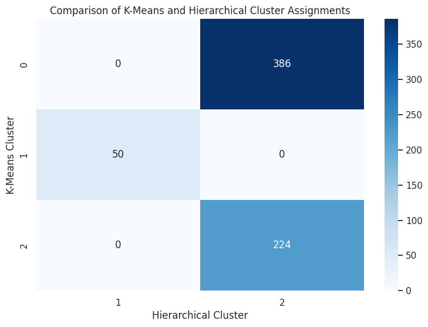

```python
plt.figure(figsize=(9, 6))

sns.heatmap(
    cluster_assignment_comparison,
    annot=True,
    fmt='d',
    cmap='Blues'
)

plt.title('Comparison of K-Means and Hierarchical Cluster Assignments')
plt.xlabel('Hierarchical Cluster')
plt.ylabel('K-Means Cluster')

plt.show()
```

### Observation — Cluster Assignment Comparison

The cross-tabulation shows how customers assigned to K-Means clusters are distributed across the hierarchical clusters.

A strong concentration along particular combinations indicates that both methods identify similar groups of customers, even though their cluster labels may differ.

Where substantial differences exist, the corresponding cluster profiles are examined to determine whether the methods are identifying genuinely different customer structures.

### Overall Comparison Table

```python
final_comparison = pd.DataFrame({
    'Criteria': [
        'Number of Clusters',
        'Silhouette Score',
        'Computation Time (seconds)',
        'Methodology',
        'Scalability',
        'Interpretability'
    ],
    'K-Means': [
        len(np.unique(kmeans_comparison_labels)),
        round(kmeans_silhouette, 4),
        round(kmeans_time, 6),
        'Centroid-based partitioning',
        'More scalable for large datasets',
        'Easy to interpret'
    ],
    'Hierarchical': [
        len(np.unique(hierarchical_comparison_labels)),
        round(hierarchical_silhouette, 4),
        round(hierarchical_time, 6),
        f'Agglomerative ({best_linkage.capitalize()} linkage)',
        'More computationally intensive',
        'Provides hierarchical structure'
    ]
})

final_comparison
```

|  | Criteria | K-Means | Hierarchical |
| --- | --- | --- | --- |
| 0 | Number of Clusters | 3 | 2 |
| 1 | Silhouette Score | 0.52 | 0.52 |
| 2 | Computation Time (seconds) | 0.07 | 0.05 |
| 3 | Methodology | Centroid-based partitioning | Agglomerative (Average linkage) |
| 4 | Scalability | More scalable for large datasets | More computationally intensive |
| 5 | Interpretability | Easy to interpret | Provides hierarchical structure |

## 5.1 Final Comparison and Method Selection

Both K-Means and hierarchical clustering produced meaningful customer segments based on the financial and interaction variables.

The comparison was performed using cluster profiles, cluster assignment overlap, Silhouette Score, and computation time.

The alternative clustering method remains useful as a validation approach because it provides an independent view of the customer segmentation structure.

### Business Interpretation

The comparison of K-Means and hierarchical clustering demonstrates that customer segmentation is reasonably robust when multiple unsupervised learning techniques are considered.

The final segmentation should prioritize a solution that produces:

1. Clearly differentiated customer groups.
2. Meaningful financial and interaction profiles.
3. Sufficiently large groups for practical marketing campaigns.
4. Actionable differences in customer-service requirements.
5. Appropriate computational efficiency for future scaling.

The selected clustering solution will therefore be used as the primary basis for the customer personas and business recommendations in the next section.

## 5.2 K-Means vs Hierarchical Clustering — Summary

K-Means and hierarchical clustering were evaluated using the same standardized customer dataset.

The comparison considered cluster sizes, cluster profiles, cluster assignment overlap, Silhouette Score, and computation time.

Both methods provide useful perspectives on the underlying customer structure. K-Means provides a direct centroid-based segmentation, while hierarchical clustering provides a hierarchical representation of customer similarity.

The final method is selected based on the combined evidence from clustering quality, computational efficiency, and business interpretability rather than relying on a single metric.

## 6. Actionable Insights & Recommendations

The clustering analysis identified distinct customer groups based on financial characteristics and interaction behavior.

The customer segments provide AllLife Bank with an opportunity to move from a one-size-fits-all approach toward differentiated marketing and service strategies.

The recommendations below are based directly on the observed cluster profiles, including average credit limit, credit-card ownership, branch visits, online engagement, and call-center interactions.

### 6.1 Customer Segment Overview

The K-Means solution identified three customer segments with distinct financial and interaction characteristics:

| Segment | Key Characteristics | Business Interpretation |
| --- | --- | --- |
| Cluster 0 | Moderate-high credit limit, relatively high credit-card ownership, frequent branch visits, low online usage, moderate calls | Branch-oriented, financially established customers |
| Cluster 1 | Very high credit limit, highest credit-card ownership, very high online engagement, low branch visits and calls | High-value, digitally engaged customers |
| Cluster 2 | Low credit limit, low credit-card ownership, moderate online usage, high call-center usage | Lower-value, high-service-contact customers |

These segments demonstrate meaningful differences in both financial value and preferred interaction channels.

### 6.2 Cluster 0 — Branch-Oriented, Financially Established Customers

Cluster 0 is the largest K-Means segment, containing approximately 386 customers.

The segment has an average credit limit of approximately 33,782 and customers hold around 5.5 credit cards on average.

The most distinctive behavioral characteristic is the relatively high number of bank visits, averaging approximately 3.5 visits per year. Online activity is comparatively low, at approximately 1 visit per year.

This indicates that these customers are relatively financially established but show a stronger preference for physical branch interactions than digital channels.

### Marketing Recommendations

1. **Branch-based cross-selling:** Use branch interactions as an opportunity to promote relevant credit-card upgrades, complementary financial products, and relationship-based offerings.
2. **Personalized offers:** Use existing credit-card ownership and credit-limit information to identify customers who may be suitable for higher-tier products.
3. **Digital adoption campaigns:** Introduce targeted incentives and demonstrations to encourage customers to use online banking services for routine activities.
4. **Relationship-based engagement:** Since these customers interact relatively frequently with branches, branch staff can use these interactions to understand customer needs and recommend suitable products.

### Service Recommendations

1. Provide efficient branch-based support because this segment demonstrates relatively high physical branch usage.
2. Encourage migration of routine transactions and queries to digital channels to reduce unnecessary branch dependency.
3. Provide digital onboarding or demonstrations for customers who are less familiar with online banking.
4. Maintain personalized branch support for complex financial requirements where physical interaction adds value.

### 6.3 Cluster 1 — High-Value, Digitally Engaged Customers

Cluster 1 contains approximately 50 customers and represents a relatively small but highly valuable customer segment.

The average credit limit is approximately 141,040, substantially higher than the other K-Means clusters. Customers hold approximately 8.7 credit cards on average, which is also the highest among the three segments.

These customers are highly digitally engaged, averaging approximately 10.9 online visits per year, while making very few branch visits and calls.

The combination of high financial value and strong digital engagement makes this segment strategically important to AllLife Bank.

### Marketing Recommendations

1. **Premium product targeting:** Prioritize this segment for premium credit-card products and high-value financial offerings.
2. **Upselling and cross-selling:** Customers with high credit limits and multiple credit cards may be suitable candidates for carefully targeted additional products.
3. **Digital-first campaigns:** Use online and mobile channels as the primary communication channels because these customers demonstrate strong digital engagement.
4. **Personalized offers:** Develop highly personalized campaigns based on the customer's existing relationship and product portfolio rather than broad promotional campaigns.
5. **Customer retention:** Since this group represents high-value customers, retention-oriented campaigns should be prioritized to protect the bank's high-value customer base.

### Service Recommendations

1. Prioritize digital self-service capabilities because these customers already demonstrate strong online engagement.
2. Provide seamless digital support for account and credit-card queries.
3. Use proactive digital notifications and online assistance to reduce the need for branch or call-center interactions.
4. Consider dedicated digital support or premium service channels for high-value customers where appropriate.

### 6.4 Cluster 2 — Lower-Value, High-Service-Contact Customers

Cluster 2 contains approximately 224 customers.

The segment has the lowest average credit limit, approximately 12,174, and customers hold around 2.4 credit cards on average.

The most distinctive characteristic is the high number of calls made to the bank, averaging approximately 6.9 calls per year. Online activity is moderate, while branch visits are relatively low.

The combination of relatively low credit-card ownership and high call-center usage suggests that this segment may require greater assisted support.

### Marketing Recommendations

1. **Targeted product education:** Provide customers with clear information about suitable credit-card products and benefits before attempting aggressive upselling.
2. **Needs-based offers:** Use customer interaction history to identify relevant products rather than sending broad promotional campaigns.
3. **Digital education:** Encourage customers to use online channels for routine activities through simple tutorials, onboarding, and guided digital journeys.
4. **Gradual relationship expansion:** Customers with lower credit-card ownership can be considered for carefully selected products when there is evidence of suitability and engagement.

### Service Recommendations

1. **Reduce unnecessary call-center dependency:** Identify frequently requested services that can be migrated to online self-service.
2. **Improve digital self-service:** Provide simpler online processes for common customer queries.
3. **Proactive communication:** Use notifications and FAQs to address common questions before customers need to call the bank.
4. **Call-center analysis:** Analyze the reasons behind the high call frequency and prioritize process improvements for the most common query types.
5. **Assisted digital support:** Provide guided support to help customers transition from call-based interactions to digital channels.

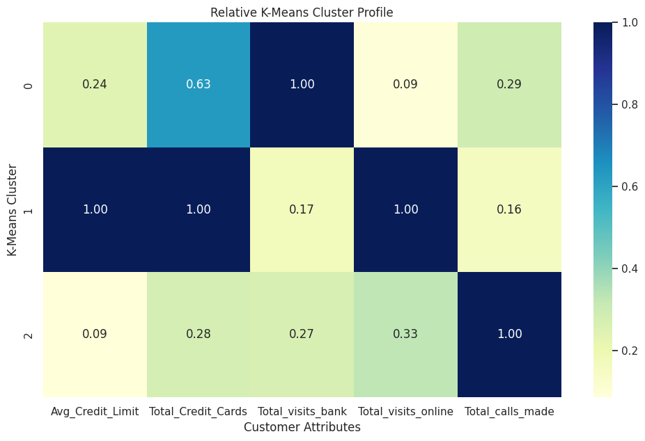

```python
# Create a normalized cluster profile for visualization

cluster_profile_normalized = (
    cluster_profile_comparison /
    cluster_profile_comparison.max()
)

plt.figure(figsize=(12, 7))

sns.heatmap(
    cluster_profile_normalized,
    annot=True,
    fmt='.2f',
    cmap='YlGnBu'
)

plt.title('Relative K-Means Cluster Profile')
plt.xlabel('Customer Attributes')
plt.ylabel('K-Means Cluster')

plt.show()
```

## 6.5 Segment-Specific Marketing Strategy

| Customer Segment | Primary Objective | Recommended Marketing Approach |
| --- | --- | --- |
| Cluster 0 — Branch-Oriented, Financially Established | Increase relationship value and digital adoption | Branch-based cross-selling, personalized offers, digital adoption campaigns |
| Cluster 1 — High-Value, Digitally Engaged | Retain and grow high-value relationships | Premium products, personalized digital campaigns, upselling and cross-selling |
| Cluster 2 — Lower-Value, High-Service-Contact | Build engagement while reducing service friction | Needs-based offers, product education, digital adoption and targeted campaigns |

## 6.6 Segment-Specific Service Strategy

| Customer Segment | Service Challenge | Recommended Operational Strategy |
| --- | --- | --- |
| Cluster 0 | Relatively high branch dependency | Improve branch efficiency and encourage digital migration for routine services |
| Cluster 1 | High-value customers with strong digital preference | Provide seamless digital and premium support |
| Cluster 2 | High call-center usage | Improve self-service, proactive communication, and call-center query resolution |

## 6.7 Overall Business Recommendations

Based on the customer segmentation analysis, AllLife Bank should adopt a differentiated customer-management strategy.

### 1. Prioritize high-value customers

Cluster 1 represents a small but highly valuable group with substantially higher credit limits and credit-card ownership. The bank should prioritize retention, premium offerings, and personalized digital campaigns for this segment.

### 2. Increase digital adoption among branch-oriented customers

Cluster 0 demonstrates relatively frequent branch usage and low online engagement. The bank can use branch interactions to introduce customers to digital banking services and migrate routine activities online.

### 3. Reduce unnecessary call-center interactions

Cluster 2 has the highest average call-center usage. The bank should investigate the underlying reasons for these calls and improve online self-service capabilities for frequently requested services.

### 4. Use customer financial profiles for targeted campaigns

Credit limits and credit-card ownership can be used to identify customers who may be suitable for relevant upgrades or additional products. Marketing should remain needs-based rather than relying on blanket campaigns.

### 5. Develop channel-specific communication

The analysis indicates different channel preferences across customer groups. Therefore, the bank should use digital channels for digitally engaged customers, branch interactions for branch-oriented customers, and assisted/digital support for high-call customers.

### 6. Use segmentation as an ongoing decision-support tool

The identified segments can be incorporated into marketing and service workflows so that customer communication and support can be tailored according to financial value and interaction behavior.

## 6.9 Final Actionable Insights

The clustering analysis indicates that AllLife Bank's customer base is heterogeneous and can be differentiated into meaningful groups based on financial value and interaction behavior.

The most strategically important segment is the high-value, digitally engaged group, which has substantially higher average credit limits and credit-card ownership. This group should receive personalized retention, premium-product, and digital engagement strategies.

The branch-oriented segment represents a large customer population with relatively strong financial characteristics but low digital usage. The bank can use existing branch relationships to increase digital adoption while continuing relationship-based cross-selling.

The lower-value, high-service-contact segment presents an operational opportunity. Its high call-center usage suggests that improving self-service capabilities and understanding common customer queries could reduce service friction while gradually increasing customer engagement.

Overall, the segmentation enables AllLife Bank to align marketing and operations strategies with customer characteristics rather than applying the same approach to the entire customer base.